# Mileage - Vehicle's Price Predictor

## M.Sc. in Big Data & Data Science Thesis - Universidad Complutense de Madrid

### Alvaro Lozano

#### September 3rd, 2021

**www.mileage.one**

Mileage is a master's thesis in big data and data science by Alvaro Lozano from the Complutense University of Madrid that aims to generate predictions about the value of vehicles given certain characteristics.

The motivation for this project was to put into practice the knowledge acquired during the course to develop a fully functional tool. With this project, the student wanted to challenge itself, expanding its limits and looking for solutions to all the problems that have arisen, in order to prepare itself for a professional data science environment.

Organisationally, a strategy has been followed that tries to tackle first those phases that posed the most problems, progressing from simple solutions to the more complex ones implemented in the final project. This way of working allowed the student to have absolute control, in the way that having solved the problems at the beginning ensured that there were no major obstacles to reaching the final goal.

Several resources have been used to carry out the project, such as Google Cloud Platform (instance of AI Notebooks), Kaggle, Kaggle Kernel, Django and Github, among others. The main programming language used was Python, but also, HTML, Javascript, CSS and Bash.

The project basic structure is the following:

1. Project Goal
2. Data Load
3. Exploratory Data Analysis
4. Data Cleaning and Feature Engineering
5. Dataset Splitting
6. Modeling
7. Model Deployment
8. Sources

# 1. Project Goal

##### The goal of this project is to deploy an online service that estimates the price of a vehicle given certain characteristics. To achieve it, a regression model is built from scratch using a dataset of cars from the United States of America.

# 2. Dataset Load

## 2.1. System Specs and running time

```python
# Timer
import time
start_time = time.time()

import platform,socket,re,uuid,json,psutil,logging
from datetime import date
def getSystemInfo():
    try:
        info={}
        info['platform']=platform.system()
        info['platform-release']=platform.release()
        info['platform-version']=platform.version()
        info['architecture']=platform.machine()
        info['hostname']=socket.gethostname()
        info['ip-address']=socket.gethostbyname(socket.gethostname())
        info['mac-address']=':'.join(re.findall('..', '%012x' % uuid.getnode()))
        info['processor']=platform.processor()
        info['ram']=str(round(psutil.virtual_memory().total / (1024.0 **3)))+" GB"
        info['date']=str(date.today())
        return json.dumps(info)
    except Exception as e:
        logging.exception(e)

json.loads(getSystemInfo())
```

```
{'platform': 'Linux',
 'platform-release': '4.19.0-17-cloud-amd64',
 'platform-version': '#1 SMP Debian 4.19.194-3 (2021-07-18)',
 'architecture': 'x86_64',
 'hostname': '218d87bb619d',
 'ip-address': '172.17.0.2',
 'mac-address': '02:42:ac:11:00:02',
 'processor': 'x86_64',
 'ram': '63 GB',
 'date': '2021-09-03'}
```

## 2.2. Libraries load, parameters set and data load

##### Data is loded from Kaggle, some libraries are imported and notebooks parameters are set.

Pandas and numpy are loaded for general purposes along the script.  
Sklearn and catboost are needed for the model.  
Matplotlib and seaborn are loaded for some graphic representations.  
The package sweetviz was used to perfom a quick EDA.

```python
# Libraries
import pandas as pd
import numpy as np
from matplotlib import pyplot as plt
import seaborn as sns
from scipy import stats
from catboost import CatBoostRegressor
from sklearn.model_selection import train_test_split
from sklearn.metrics import mean_squared_error
from sklearn.metrics import r2_score
from sklearn import preprocessing
!pip install sweetviz
import sweetviz
```

```
WARNING: Running pip as the 'root' user can result in broken permissions and conflicting behaviour with the system package manager. It is recommended to use a virtual environment instead: https://pip.pypa.io/warnings/venv
```

Some visualizations parameters where set in order to see more rows and variables on the screen.

```python
pd.set_option('display.max_rows', 500)
pd.set_option('display.max_columns', 500)
```

Data load and overview

```python
# Dataset load
cars = pd.read_csv("/kaggle/input/us-used-cars-dataset/used_cars_data.csv")

# Dataset overview
cars.head(2)
```

|  | vin | back_legroom | bed | bed_height | bed_length | body_type | cabin | city | city_fuel_economy | combine_fuel_economy | daysonmarket | dealer_zip | description | engine_cylinders | engine_displacement | engine_type | exterior_color | fleet | frame_damaged | franchise_dealer | franchise_make | front_legroom | fuel_tank_volume | fuel_type | has_accidents | height | highway_fuel_economy | horsepower | interior_color | … |
| --- | --- | --- | --- | --- | --- | --- | --- | --- | --- | --- | --- | --- | --- | --- | --- | --- | --- | --- | --- | --- | --- | --- | --- | --- | --- | --- | --- | --- | --- | --- |
| 0 | ZACNJABB5KPJ92081 | 35.1 in | NaN | NaN | NaN | SUV / Crossover | NaN | Bayamon | NaN | NaN | 522 | 960 | [!@@Additional Info@@!]Engine: 2.4L I4 ZERO EV... | I4 | 1300.0 | I4 | Solar Yellow | NaN | NaN | True | Jeep | 41.2 in | 12.7 gal | Gasoline | NaN | 66.5 in | NaN | 177.0 | Black | … |
| 1 | SALCJ2FX1LH858117 | 38.1 in | NaN | NaN | NaN | SUV / Crossover | NaN | San Juan | NaN | NaN | 207 | 922 | [!@@Additional Info@@!]Keyless Entry,Ebony Mor... | I4 | 2000.0 | I4 | Narvik Black | NaN | NaN | True | Land Rover | 39.1 in | 17.7 gal | Gasoline | NaN | 68 in | NaN | 246.0 | Black (Ebony) | … |

# 3. Exploratory Data Analysis

##### During this part, the influence of the variables on the target variable is studied and missing or erroneous values are detected.

## 3.1. Variables of the dataset

### 3.1.1. Variables' definition

A short description of the variables of the dataset.

**0 vin:** Vehicle Identification Number is a unique encoded string for every vehicle. A vehicle identification number (VIN) (also called a chassis number or frame number) is a unique code, including a serial number, used by the automotive industry to identify individual motor vehicles, towed vehicles, motorcycles, scooters and mopeds, as defined in ISO 3779 (content and structure) and ISO 4030 (location and attachment).  
**1. back_legroom:** Legroom in the rear seat measured in inches.  
**2. bed:** Category of bed size (open cargo area) in pickup truck. Null usually means the vehicle isn't a pickup truck.  
**3. bed_height:** Height of bed in inches.  
**4. bed_length:** Length of bed in inches.  
**5. body_type:** Body Type of the vehicle. Like Convertible, Hatchback, Sedan, etc.  
**6. cabin:** Category of cabin size (open cargo area) in pickup truck. Eg: Crew Cab, Extended Cab, etc.  
**7. city:** City where the car is listed. Eg: Houston, San Antonio, etc.  
**8. city_fuel_economy:** Fuel economy in city traffic in km per litre.  
**9. combine_fuel_economy:** Combined fuel economy is a weighted average of City and Highway fuel economy in km per litre.  
**10. daysonmarket:** Days since the vehicle was first listed on the website.  
**11. dealer_zip:** Zipcode of the dealer.  
**12. description:** Vehicle description on the vehicle's listing page.  
**13. engine_cylinders:** The engine configuration. Eg: I4, V6, etc.  
**14. engine_displacement:** Engine displacement is the measure of the cylinder volume swept by all of the pistons of a piston engine, excluding the combustion chambers.  
**15. engine_type:** The engine configuration. Eg: I4, V6, etc.  
**16. exterior_color:** Exterior color of the vehicle, usually a fancy one same as the brochure.  
**17. fleet:** Whether the vehicle was previously part of a fleet.  
**18. frame_damaged:** Whether the vehicle has a damaged frame.  
**19. franchise_dealer:** Whether the dealer is a franchise dealer.  
**20. franchise_make:** The company that owns the franchise.  
**21. front_legroom:** The legroom in inches for the passenger seat.  
**22. fuel_tank_volume:** Fuel tank's filling capacity in gallons.  
**23. fuel_type:** Dominant type of fuel ingested by the vehicle.  
**24. has_accidents:** Whether the vin has any accidents registered.  
**25. height:** Height of the vehicle in inches.  
**26. highway_fuel_economy:** Fuel economy in highway traffic in km per litre.  
**27. horsepower:** Horsepower is the power produced by an engine.  
**28. interior_color:** Interior color of the vehicle, usually a fancy one same as the brochure.  
**29. isCab:** Whether the vehicle was previously taxi/cab.  
**30. is_certified:** Whether the vehicle is certified. Certified cars are covered through warranty period.  
**31. is_cpo:** Pre-owned cars certified by the dealer. Certified vehicles come with a manufacturer warranty for free repairs for a certain time period.  
**32. is_new:** If True means the vehicle was launched less than 2 years ago.  
**33. is_oemcpo:** Pre-owned cars certified by the manufacturer.  
**34. latitude:** Latitude from the geolocation of the dealership.  
**35. length:** Length of the vehicle in inches.  
**36. listed_date:** The date the vehicle was listed on the website. Does not make daysonmarket obsolete. The prices is dayson_market days after the listed date.  
**37. listing_color:** Dominant color group from the exterior color.  
**38. listing_id:** Listing id from the website.  
**39. longitude:** Longitude from the geolocation of the dealership.  
**40. main_picture_url:** URL of the vehicle's picture.  
**41. major_options:** Optional packages of the vehicle.  
**42. make_name:** Vehicle's brand.  
**43. maximum_seating:** Total number of seats.  
**44. mileage:** Refers to the distance that the vehicle has travelled, measured in miles.  
**45. model_name:** Model name of the vehicle.  
**46. owner_count:** Number of owners the vehicle has had along its life.  
**47. power:** Maximum power of the vehicle and the rpm to develop the power.  
**48. price:** Sale price of the vehicle on the website.  
**49. salvage:** In North America, a salvage title is a form of vehicle title branding, which notes that the vehicle has been damaged and/or deemed a total loss by an insurance company that paid a claim on it.  
**50. savings_amount:** Non defined variable.  
**51. seller_rating:** The Seller Rating is created by data received from buyers in an effort to measure the quality of the experience you provide your customers.  
**52. sp_id:** Dealer id.  
**53. sp_name:** Dealer name.  
**54. theft_title:** Vehicle that was stolen and later recovered.  
**55. torque:** Torque indicates the force to which the drive shaft is subjected. Also the revolutions needed to reach the maximum torque.  
**56. transmission:** Type of transmission, such as Automatic, Manual, etc.  
**57. transmission_display:** Number of gears and type of transmission.  
**58. trimId:** Number of a particular version of a model with a particular set of configuration.  
**59. trim_name:** Name of a particular version of a model with a particular set of configuration.  
**60. vehicle_damage_category:** Category of a vehicle's damage, such as Category A meaning a ‘Scrap’ car.  
**61. wheel_system:** Traction system of a vehicle, such as AWD or FWD.  
**62. wheel_system_display:** Traction system of a vehicle, such as All Wheel Drive or Front Wheel Drive.  
**63. wheelbase:** The distance between the front and rear axles of a vehicle.  
**64. width:** The distance between both sides of a vehicle.  
**65. year:** The year the car was built.

### 3.1.2. Observations about variables

Due to the nature of some variables and the final purpose of this project, they are not valid and therefore have to be discarded.

These variables are: 'latitude', 'longitude', 'vin', 'city', 'dealer_zip', 'back_legroom', 'front_legroom', 'height', 'length', 'wheelbase', 'width', 'daysonmarket', 'listing_id', 'sp_id', 'listed_date', 'main_picture_url', 'savings_amount', 'sp_name', 'trim_name', 'trimId', 'franchise_dealer', 'seller_rating', 'franchise_make', 'description', 'major_options', 'interior_color', 'engine_cylinders', 'wheel_system_display' and 'exterior_color'.

**The reasons to delete these variables are detailed in the section 4.3.**

## 3.2. Numeric variables overview

The first analysis to perform on the dataset is common sense. Some results are visualised for the numerical variables.

### 3.2.1. Numeric description

```python
cars.describe()
```

|  | city_fuel_economy | combine_fuel_economy | daysonmarket | engine_displacement | highway_fuel_economy | horsepower | is_certified | latitude | listing_id | longitude | mileage | owner_count | price | savings_amount | seller_rating | sp_id | vehicle_damage_category | year |
| --- | --- | --- | --- | --- | --- | --- | --- | --- | --- | --- | --- | --- | --- | --- | --- | --- | --- | --- |
| count | 2.508755e+06 | 0.0 | 3.000040e+06 | 2.827654e+06 | 2.508755e+06 | 2.827654e+06 | 0.0 | 3.000040e+06 | 3.000040e+06 | 3.000040e+06 | 2.855653e+06 | 1.483027e+06 | 3.000040e+06 | 3.000040e+06 | 2.959168e+06 | 2.999944e+06 | 0.0 | 3.000040e+06 |
| mean | 2.269325e+01 | NaN | 7.605973e+01 | 2.968488e+03 | 2.947337e+01 | 2.479957e+02 | NaN | 3.698414e+01 | 2.754987e+08 | -9.064224e+01 | 3.114690e+04 | 1.532644e+00 | 2.993337e+04 | 5.509768e+02 | 4.270413e+00 | 2.335224e+05 | NaN | 2.017728e+03 |
| std | 8.807024e+00 | NaN | 1.088839e+02 | 1.348905e+03 | 7.769252e+00 | 9.046639e+01 | NaN | 4.996819e+00 | 8.894123e+06 | 1.390589e+01 | 7.458675e+04 | 9.202928e-01 | 1.956617e+04 | 1.079448e+03 | 5.133017e-01 | 1.323221e+05 | NaN | 4.178701e+00 |
| min | 7.000000e+00 | NaN | 0.000000e+00 | 7.000000e+02 | 1.000000e+01 | 5.500000e+01 | NaN | 1.834670e+01 | 1.994620e+07 | -1.579280e+02 | 0.000000e+00 | 1.000000e+00 | 1.650000e+02 | 0.000000e+00 | 1.000000e+00 | 4.159300e+04 | NaN | 1.915000e+03 |
| 25% | 1.800000e+01 | NaN | 1.400000e+01 | 2.000000e+03 | 2.500000e+01 | 1.750000e+02 | NaN | 3.350920e+01 | 2.745794e+08 | -9.708820e+01 | 6.000000e+00 | 1.000000e+00 | 1.845100e+04 | 0.000000e+00 | 4.000000e+00 | 6.337500e+04 | NaN | 2.017000e+03 |
| 50% | 2.100000e+01 | NaN | 3.500000e+01 | 2.500000e+03 | 2.900000e+01 | 2.440000e+02 | NaN | 3.784710e+01 | 2.785453e+08 | -8.724950e+01 | 8.267000e+03 | 1.000000e+00 | 2.647700e+04 | 0.000000e+00 | 4.341463e+00 | 2.816270e+05 | NaN | 2.020000e+03 |
| 75% | 2.600000e+01 | NaN | 8.200000e+01 | 3.600000e+03 | 3.300000e+01 | 3.000000e+02 | NaN | 4.100620e+01 | 2.804553e+08 | -8.045490e+01 | 4.366200e+04 | 2.000000e+00 | 3.822000e+04 | 7.850000e+02 | 4.605263e+00 | 3.366140e+05 | NaN | 2.020000e+03 |
| max | 1.270000e+02 | NaN | 3.599000e+03 | 8.400000e+03 | 1.270000e+02 | 1.001000e+03 | NaN | 6.120310e+01 | 2.820222e+08 | -6.607850e+01 | 9.999999e+07 | 1.900000e+01 | 3.299995e+06 | 1.474140e+05 | 5.000000e+00 | 4.409510e+05 | NaN | 2.021000e+03 |

**Comments:**  
The first thing we notice when looking at the dataset is that there are high values for the variable "mileage". Surprisingly, the model performed better when no record was deleted.

### 3.2.2. Plots of the numeric variables

#### 3.2.2.1. Boxplots

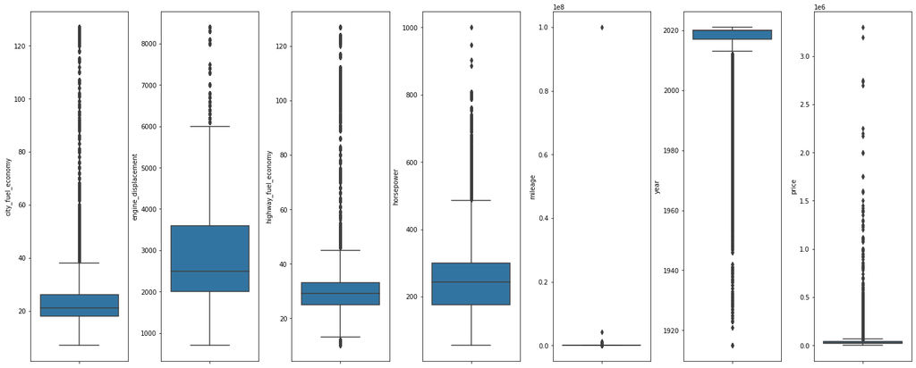

```python
aux = cars[["city_fuel_economy", "engine_displacement", "highway_fuel_economy", "horsepower", "mileage", "year", "price"]]
fig, axs = plt.subplots(ncols=7, nrows=1, figsize=(20, 8))
index = 0
axs = axs.flatten()
for k,v in aux.items():
    sns.boxplot(y=k, data=aux, ax=axs[index])
    index += 1
plt.tight_layout(pad=0.4, w_pad=0.5, h_pad=5.0)
```

#### 3.2.2.2. Histograms

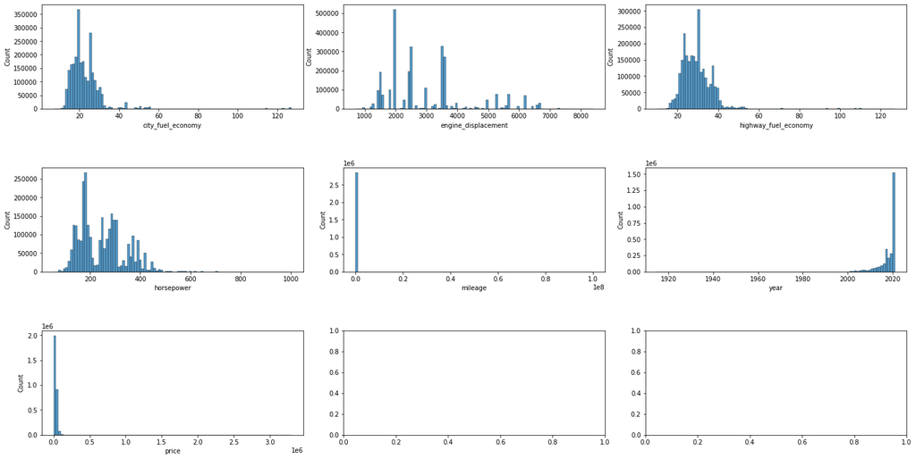

```python
fig, axs = plt.subplots(ncols=3, nrows=3, figsize=(20, 10))
index = 0
axs = axs.flatten()
for k,v in aux.items():
    sns.histplot(v, ax=axs[index], bins=100)
    index += 1
plt.tight_layout(pad=0.4, w_pad=0.5, h_pad=5.0)
```

**Comments:**  
The distributions for the variables look good except for the variable mileage that seems to have an outlier.

#### 3.2.2.3. Correlation plot

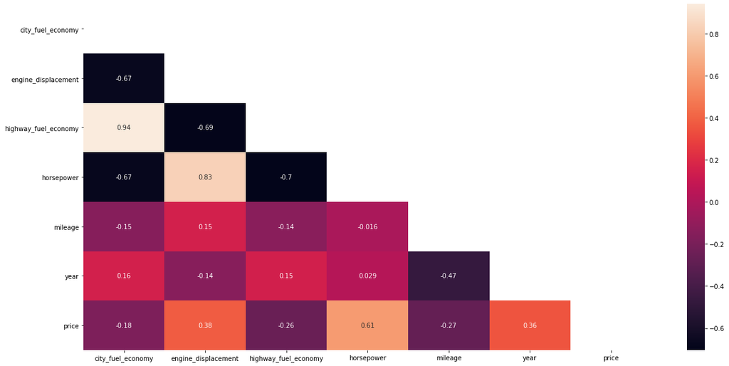

```python
plt.figure(figsize=(20, 10))
corr = aux.corr()
matrix = np.triu(corr)
sns.heatmap(corr,  annot=True, mask=matrix)
```

#### 3.2.2.4. Regression plots

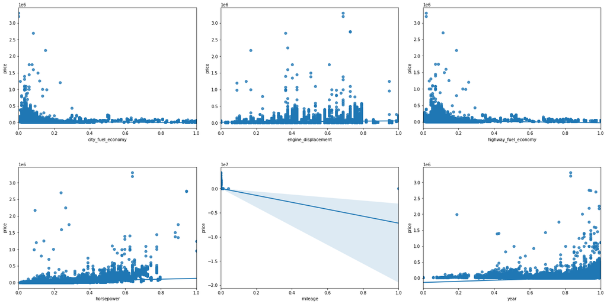

```python
# Let's scale the columns before plotting them against price
min_max_scaler = preprocessing.MinMaxScaler()
column_sels = ["city_fuel_economy", "engine_displacement", "highway_fuel_economy", "horsepower", "mileage", "year"]
x = aux.loc[:,column_sels]
y = aux['price']
x = pd.DataFrame(data=min_max_scaler.fit_transform(x), columns=column_sels)
fig, axs = plt.subplots(ncols=3, nrows=2, figsize=(20, 10))
index = 0
axs = axs.flatten()
for i, k in enumerate(column_sels):
    sns.regplot(y=y, x=x[k], ax=axs[i])
plt.tight_layout(pad=0.4, w_pad=0.5, h_pad=5.0)
del aux
```

**Comments:**  
Here we can see again the correlation that we just saw on the previous plot.

### 3.2.3. Observations about the numeric variables.

All of the chosen numeric variables have correlations with price and they are probably going to be useful for the model.

## 3.3. Categorical variables overview

### 3.3.1. Numeric description

```python
cars_cat = cars.select_dtypes(include = 'object').copy()
cars_cat_stats = pd.DataFrame(columns = ['column', 'values', 'values_count_incna', 'values_count_nona',
                                         'num_miss', 'pct_miss'])
tmp = pd.DataFrame()

for c in cars_cat.columns:
    tmp['column'] = [c]
    tmp['values'] = [cars_cat[c].unique()]
    tmp['values_count_incna'] = len(list(cars_cat[c].unique()))
    tmp['values_count_nona'] = int(cars_cat[c].nunique())
    tmp['num_miss'] = cars_cat[c].isnull().sum()
    tmp['pct_miss'] = (cars_cat[c].isnull().sum()/ len(cars_cat)).round(3)*100
    cars_cat_stats = cars_cat_stats.append(tmp)

# Let's do an Ascending sort on the number of distinct categories for each categorical variable
cars_cat_stats.sort_values(by = 'values_count_incna', inplace = True, ascending = True)

# And set the index to column names
cars_cat_stats.set_index('column', inplace = True)
cars_cat_stats
```

| column | values | values_count_incna | values_count_nona | num_miss | pct_miss |
| --- | --- | --- | --- | --- | --- |
| is_oemcpo | [nan, True] | 2 | 1 | 2864678 | 95.5 |
| is_cpo | [nan, True] | 2 | 1 | 2817142 | 93.9 |
| bed_height | [nan, --] | 2 | 1 | 2570942 | 85.7 |
| isCab | [nan, False, True] | 3 | 2 | 1426595 | 47.6 |
| salvage | [nan, False, True] | 3 | 2 | 1426595 | 47.6 |
| theft_title | [nan, False, True] | 3 | 2 | 1426595 | 47.6 |
| has_accidents | [nan, False, True] | 3 | 2 | 1426595 | 47.6 |
| frame_damaged | [nan, False, True] | 3 | 2 | 1426595 | 47.6 |
| fleet | [nan, False, True] | 3 | 2 | 1426595 | 47.6 |
| bed | [nan, Short, Long, Regular] | 4 | 3 | 2980472 | 99.3 |
| transmission | [A, M, CVT, nan, Dual Clutch] | 5 | 4 | 64185 | 2.1 |
| cabin | [nan, Crew Cab, Extended Cab, Regular Cab, Lar... | 5 | 4 | 2936507 | 97.9 |
| wheel_system_display | [Front-Wheel Drive, All-Wheel Drive, Rear-Whee... | 6 | 5 | 146732 | 4.9 |
| wheel_system | [FWD, AWD, RWD, 4WD, nan, 4X2] | 6 | 5 | 146732 | 4.9 |
| fuel_type | [Gasoline, Diesel, nan, Biodiesel, Flex Fuel V... | 9 | 8 | 82724 | 2.8 |
| body_type | [SUV / Crossover, Sedan, Coupe, Hatchback, Pic... | 10 | 9 | 13543 | 0.5 |
| maximum_seating | [5 seats, 7 seats, 2 seats, 4 seats, 8 seats, ... | 13 | 12 | 159269 | 5.3 |
| listing_color | [YELLOW, BLACK, UNKNOWN, GRAY, SILVER, WHITE, ... | 15 | 15 | 0 | 0.0 |
| engine_cylinders | [I4, H4, V6, I6, V6 Diesel, nan, V8, V8 Biodie... | 40 | 39 | 100581 | 3.4 |
| engine_type | [I4, H4, V6, I6, V6 Diesel, nan, V8, V8 Biodie... | 40 | 39 | 100581 | 3.4 |
| transmission_display | [9-Speed Automatic Overdrive, 6-Speed Manual, ... | 45 | 44 | 64185 | 2.1 |
| franchise_make | [Jeep, Land Rover, FIAT, Chevrolet, Cadillac, ... | 49 | 48 | 572635 | 19.1 |
| bed_length | [nan, 78.9 in, --, 81.9 in, 74 in, 67.4 in, 69... | 84 | 83 | 2570942 | 85.7 |
| make_name | [Jeep, Land Rover, Subaru, Mazda, Alfa Romeo, ... | 100 | 100 | 0 | 0.0 |
| front_legroom | [41.2 in, 39.1 in, 43.3 in, 39 in, 40.2 in, 42... | 102 | 101 | 159269 | 5.3 |
| fuel_tank_volume | [12.7 gal, 17.7 gal, 15.9 gal, 23.5 gal, 16.6 ... | 183 | 182 | 159269 | 5.3 |
| back_legroom | [35.1 in, 38.1 in, 35.4 in, 37.6 in, 37.1 in, ... | 220 | 219 | 159269 | 5.3 |
| width | [79.6 in, 85.6 in, 78.9 in, 87.4 in, 84.4 in, ... | 286 | 285 | 159269 | 5.3 |
| height | [66.5 in, 68 in, 58.1 in, 73 in, 66.3 in, 56.9... | 473 | 472 | 159269 | 5.3 |
| wheelbase | [101.2 in, 107.9 in, 104.3 in, 115 in, 113.1 i... | 484 | 483 | 159269 | 5.3 |
| length | [166.6 in, 181 in, 180.9 in, 195.1 in, 188.9 i... | 837 | 836 | 159269 | 5.3 |
| model_name | [Renegade, Discovery Sport, WRX STI, Discovery... | 1429 | 1429 | 0 | 0.0 |
| listed_date | [2019-04-06, 2020-02-15, 2017-04-25, 2020-02-2... | 1749 | 1749 | 0 | 0.0 |
| power | [177 hp @ 5,750 RPM, 246 hp @ 5,500 RPM, 305 h... | 2038 | 2037 | 481426 | 16.0 |
| torque | [200 lb-ft @ 1,750 RPM, 269 lb-ft @ 1,400 RPM,... | 2061 | 2060 | 517793 | 17.3 |
| city | [Bayamon, San Juan, Guaynabo, Bay Shore, Bronx... | 4687 | 4687 | 0 | 0.0 |
| trim_name | [Latitude FWD, S AWD, Base, V6 HSE AWD, P250 R... | 9063 | 9062 | 116294 | 3.9 |
| dealer_zip | [960, 922, 969, 11706, 10466, 11797, 7036, 610... | 9215 | 9215 | 0 | 0.0 |
| sp_name | [Flagship Chrysler, Land Rover San Juan, FIAT ... | 26148 | 26148 | 0 | 0.0 |
| exterior_color | [Solar Yellow, Narvik Black, None, Eiger Gray,... | 28666 | 28665 | 26 | 0.0 |
| trimId | [t83804, t86759, t58994, t86074, t85614, t8525... | 41330 | 41329 | 115827 | 3.9 |
| interior_color | [Black, Black (Ebony), None, Gray (Ebony/Ebony... | 45727 | 45726 | 165 | 0.0 |
| major_options | [['Quick Order Package'], ['Adaptive Cruise Co... | 279973 | 279972 | 200048 | 6.7 |
| main_picture_url | [https://static.cargurus.com/images/forsale/20... | 2415856 | 2415855 | 369093 | 12.3 |
| description | [[!@@Additional Info@@!]Engine: 2.4L I4 ZERO E... | 2519326 | 2519325 | 77901 | 2.6 |
| vin | [ZACNJABB5KPJ92081, SALCJ2FX1LH858117, JF1VA2M... | 3000000 | 3000000 | 0 | 0.0 |

**Comments:**  
There are many variables with a very high percentage of missing values (pct_miss). Such as: "is_cpo", "is_oemcpo", "bed_height", "salvage", "isCab", "theft_title", "has_accidents", "fleet", "frame_damaged", "bed", "cabin" and "bed_length". These will be later reomeved.  
The variables "wheel_system_display" and "wheel_system" seem to be the same one but coded differently.  
Some variables need to be converted to numeric variables. These are: "maximum_seating", "transmission_display" and all those with units such as "in" or "gal" at the end.  
There are two variables that contain more than one variable inside them, these are "power" and "torque".  
Finally, there are variables that will not be considered in the model because they are not useful for the final purpose. They will not be intuitive for the user of www.mileage.one service. The variables are: "franchise_make", "bed_length", "front_legroom", "back_legroom", "width", "wheelbase", "heigth", "city", "length", "listed_date", "sp_name", "trim_name", "exterior_color", "interior_color", "trimId", "major_options", "main_picture_url", "description", "vin".

### 3.3.2. Plots of categorical variables

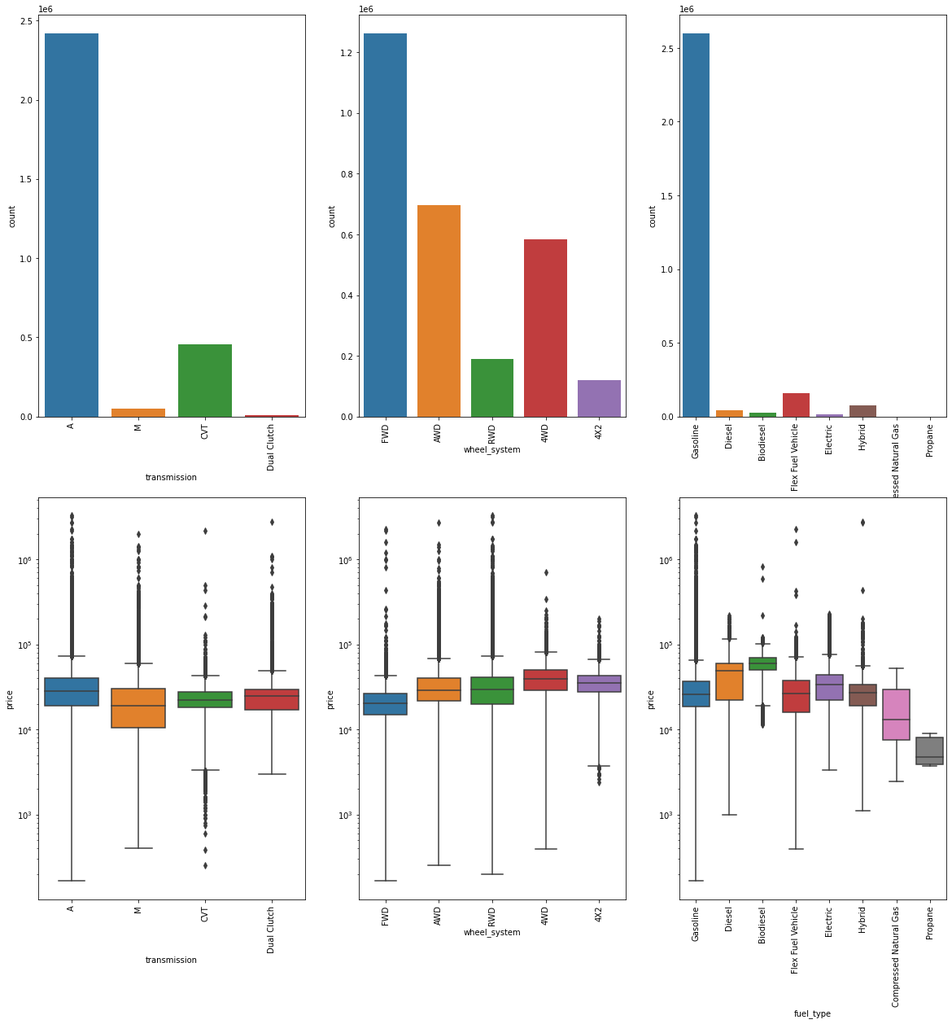

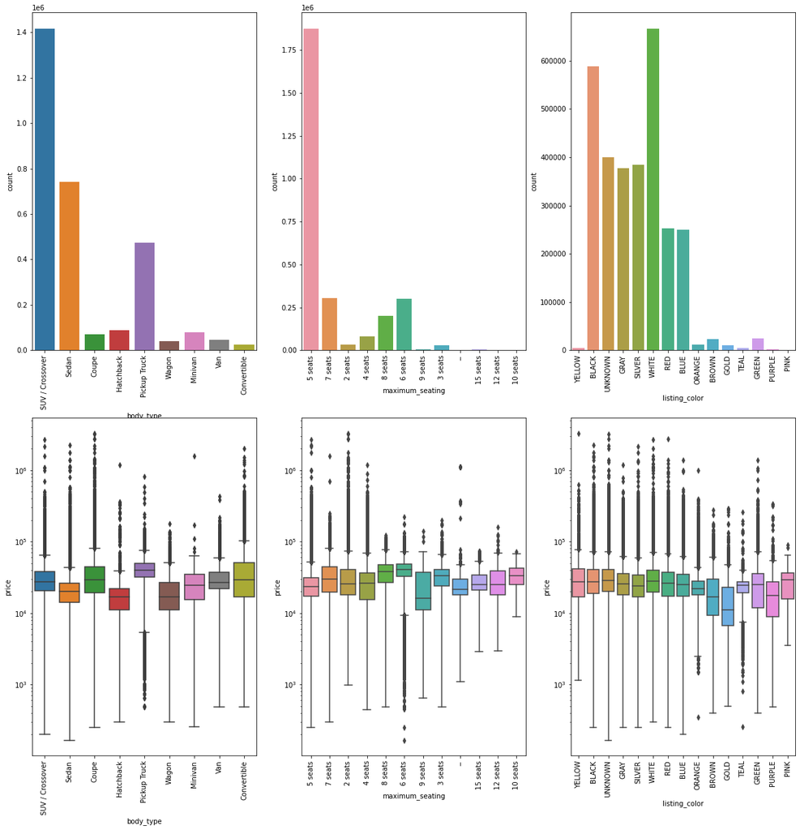

```python
cars_cat = cars_cat[["transmission", "wheel_system", "fuel_type", "body_type", "maximum_seating", "listing_color"]]
cars_cat['price'] = cars.loc[cars_cat.index, 'price'].copy()

ix = 1
fig = plt.figure(figsize = (20,20))
for c in list(cars_cat.columns):
    if ix <= 3:
        if c != 'price':
            ax1 = fig.add_subplot(2,3,ix)
            sns.countplot(data = cars_cat, x=c, ax = ax1)
            ax2 = fig.add_subplot(2,3,ix+3)
            sns.boxplot(data=cars_cat, x=c, y='price', ax=ax2)
            ax2.tick_params(axis='x', rotation=90)
            ax1.tick_params(axis='x', rotation=90)
            ax2.set_yscale("log")

    ix = ix +1
    if ix == 4:
        fig = plt.figure(figsize = (20,20))
        ix =1
```

**Comments:**  
As could be expected, being a US dataset, most of the vehicles have automatic transmission and gasoline as fuel.  
The boxplot show that the automatic cars are expected to be more expensive in mean than other transmissions.  
Actually, almost everything seems to be normal when looking at the plots, there is just one exception. The maximum_seating variable shows some problems, because some entries are wrongly coded.

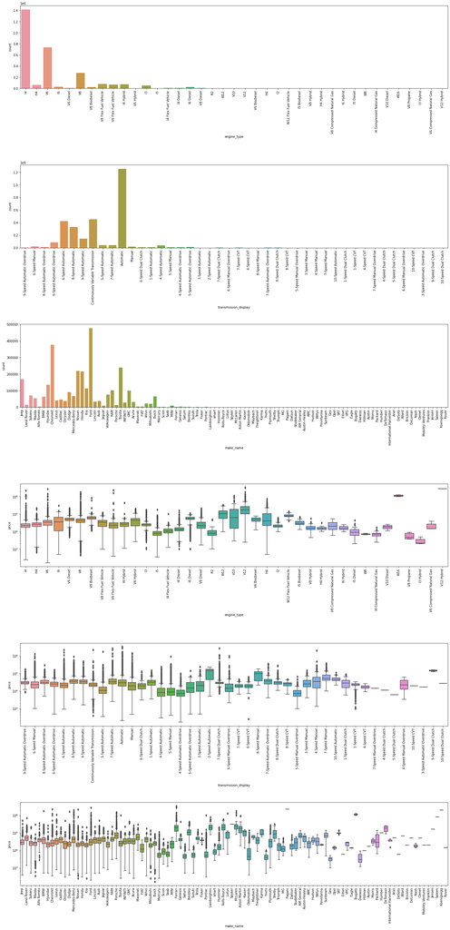

```python
cars_cat = cars.select_dtypes(include = 'object').copy()
cars_cat = cars_cat[["engine_type", "transmission_display", "make_name"]]
cars_cat['price'] = cars.loc[cars_cat.index, 'price'].copy()

ix = 1
fig = plt.figure(figsize = (20,40))
for c in list(cars_cat.columns):
    if ix <= 3:
        if c != 'price':
            ax1 = fig.add_subplot(6,1,ix)
            sns.countplot(data = cars_cat, x=c, ax = ax1)
            ax2 = fig.add_subplot(6,1,ix+3)
            sns.boxplot(data=cars_cat, x=c, y='price', ax=ax2)
            ax2.tick_params(axis='x', rotation=90)
            ax1.tick_params(axis='x', rotation=90)
            ax2.set_yscale("log")

    ix = ix +1
    if ix == 4:
        fig = plt.figure(figsize = (20,20))
        ix =1
    plt.tight_layout(pad=0.4, w_pad=0.5, h_pad=5.0)
del cars_cat
del cars_cat_stats
```

**Comments:**  
The variable "engine_type" has a mix between engine type and fuel type. We have to eliminate the fuel type because we already have a variable for this.  
The variable "transmission_display" has a mix between the number of gears and the transmission type. Since the transmission type is already in another variable, we have to remove it to keep only the numerical part.

# 4. Data Cleaning and Feature Engineering

##### This is one of the most laborious phases of the project. It consists of preprocessing the dataset for later treatment in a machine learning model.

## 4.1. Deletion of strange records

Although the EDA showed some extreme values for the variable "mileage", it ended up being better to not to delete any of them. The models performed better when all the records were present.

## 4.2. Deletion of variables with many missing records

Variables that exceed a 40% threshold missing value are deleted. These variables need to be removed because of the lack of data or other causes.

```python
threshold = 40 # The threshold is set to 40% of missing data within a variable
columns = round(cars.isnull().sum() * 100 / len(cars))
mask = cars.isnull().sum() * 100 / len(cars) > threshold
droped_cols = columns[mask]
cars = cars[columns.index[~mask]]
del columns, mask
print(droped_cols)
```

```
bed                         99.0
bed_height                  86.0
bed_length                  86.0
cabin                       98.0
combine_fuel_economy       100.0
fleet                       48.0
frame_damaged               48.0
has_accidents               48.0
isCab                       48.0
is_certified               100.0
is_cpo                      94.0
is_oemcpo                   95.0
owner_count                 51.0
salvage                     48.0
theft_title                 48.0
vehicle_damage_category    100.0
dtype: float64
```

Reasons justifying the elimination of columns:  
As can be seen above, although the limit for removing columns is equal to 40%, the columns with the lowest number of missing data have 48% of NAs. This means that practically half of the records are missing. This would be reason enough for the elimination of the variables, but in addition, many of these columns contain information that is of little use to our ultimate goal.  
The first four variables (bed, bed_height, bed_length and cabin) only apply to Pickup Truck type vehicles. These types of vehicles only represent a small proportion of the dataset and are therefore not considered for the model. The variable combine_fuel_economy would have been useful, but is 100% missing. The same goes for other variables such as fleet, frame_damaged, has_accidents, owner_count, salvage or vehicle_damage_category they could have been useful, but it is not interesting to put them in the model when they have so much missing data. There are even variables that are not described in the dataset and it is not known what they represent.

## 4.3. Deletion of variables not useful for the final goal of the project

Remember, the ultimate goal of the project is to create a model to predict the price of a vehicle using as few variables as possible so that a good result is still obtained. These variables have to be as representative as possible of a vehicle.

### 4.3.1. Variables not useful for the final model

It makes no sense to ask a customer to enter this kind of information when trying to find out the price of their vehicle.

```python
cars = cars.drop(['latitude', 'longitude', 'vin', 'city', 'dealer_zip', 'back_legroom',  'front_legroom', 'height', 'length',
                  'wheelbase', 'width'], axis=1)
```

### 4.3.2. Nonsense variables

Some variables would just make no sense on the model.

```python
cars = cars.drop(['daysonmarket', 'listing_id', 'sp_id', 'listed_date', 'main_picture_url', 'savings_amount', 'sp_name', 'trim_name',
                  'trimId', 'franchise_dealer', 'seller_rating', 'franchise_make'], axis=1)
```

### 4.3.3. Discarded variables

There are variables that were not useful for the model and were therefore discarded.

```python
cars = cars.drop(['description', 'major_options', 'interior_color'], axis=1)
```

### 4.3.4. Duplicated information

In the dataset there are some columns that contain the same or almost the same information.

```python
cars = cars.drop(['engine_cylinders', 'wheel_system_display', 'exterior_color'], axis=1)
```

## 4.4. Feature extraction

In the dataset there are two very important variables that are coded in a way that cannot be introduced in a model. Therefore, they are cleaned and treated in such a way that information is extracted from them and stored in new numeric variables.

### 4.4.1. Feature extraction from torque and power variables

```python
print("Torque variable: " + cars.torque[0] + "\nPower variable: " + cars.power[0])
```

```
Torque variable: 200 lb-ft @ 1,750 RPM
Power variable: 177 hp @ 5,750 RPM
```

Extraction of the maximum torque and the revolutions for the maximum torque and store them in two new variables.

```python
cars["torque"] = cars["torque"].str.replace(",","").astype("str")
cars["torque"] = cars["torque"].apply(lambda x: [int(i) for i in x.split() if i.isdigit()])
cars["torque"] = [x if len(x) == 2 else [0,0] for x in cars["torque"]]
cars["torque_power"] = [x[0] for x in cars["torque"]]
cars["torque_rpm"] = [x[1] for x in cars["torque"]]
```

Extraction of the maximum power and the revolutions for the maximum power and store them in two new variables.

```python
cars["power"] = cars["power"].str.replace(",","").astype("str")
cars["power"] = cars["power"].apply(lambda x: [int(i) for i in x.split() if i.isdigit()])
cars["power"] = [x if len(x) == 2 else [0,0] for x in cars["power"]]
cars["power_hp"] = [x[0] for x in cars["power"]]
cars["power_rpm"] = [x[1] for x in cars["power"]]
```

Variable after the cleaning process:

```python
print("This is how the variables look like after the cleaning:\ntorque_power: " + str(cars.torque_power[0]) + "\ntorque_rpm: " +
      str(cars.torque_rpm[0]) + "\npower_hp: " + str(cars.power_hp[0]) + "\npower_rpm: " + str(cars.power_rpm[0]))
```

```
This is how the variables look like after the cleaning:
torque_power: 200
torque_rpm: 1750
power_hp: 177
power_rpm: 5750
```

Once the extraction is completed, the original variable is deleted.

```python
cars = cars.drop(['power', 'torque'], axis=1)
```

### 4.4.2. Treatment of a duplicated variable

We have potentially duplicated variables in our dataset. These are horsepower and the just created power_hp. Horsepower contains less NA values than power_hp, so we should check if there is any case where there is an NA value in the horsepower variable and no 0 (0 is an NA) in the power_hp variable.

```python
(cars.horsepower.isna() & cars.power_hp != 0).sum()
```

```
0
```

There are no cases such the mentioned. That means that we can delete power_hp without losing information.

```python
cars.drop("power_hp", axis=1, inplace=True)
```

In order to work more comfortably, some variables were coded with 0 instead of NA. Now we have to undo this change and code them as NA.

```python
cars.power_rpm.replace(0, np.nan, inplace=True)
cars.torque_power.replace(0, np.nan, inplace=True)
cars.torque_rpm.replace(0, np.nan, inplace=True)
```

## 4.5. Cleaning variables

Treatment of variables that needed to be re-coded in different ways.

### 4.5.1. Variable transmission_display

```python
cars.transmission_display.value_counts().head(10)
```

```
Automatic                             1255101
Continuously Variable Transmission     454964
6-Speed Automatic                      425544
8-Speed Automatic                      333315
9-Speed Automatic                      146622
6-Speed Automatic Overdrive             88050
7-Speed Automatic                       44200
5-Speed Automatic                       40504
4-Speed Automatic                       36843
6-Speed Manual                          21107
Name: transmission_display, dtype: int64
```

```python
dic_trans_dis = {"Automatic": "6", "Continuously Variable Transmission": "6", "Manual": "6"}
cars["transmission_display"].replace(dic_trans_dis, inplace=True)
del dic_trans_dis
```

### 4.5.2. Variable is_new

The variable is_new contains booleans and should be changed to integer

```python
cars["is_new"] = cars["is_new"].astype(int)
```

### 4.5.3. Variables fuel_tank_volume, maximum_seating and transmission_display

Although some variables should be numeric, they are strings. It is because the variable contains the measurment unit attached to the number. The unit is removed and the variable is casted to numeric type.

```python
cars.fuel_tank_volume.value_counts().head(10)
```

```
26 gal      202824
13.2 gal    162846
18.5 gal    144687
14 gal      138947
14.5 gal     99624
15.9 gal     92611
19 gal       77054
19.5 gal     76583
24 gal       71027
18 gal       64916
Name: fuel_tank_volume, dtype: int64
```

```python
cars.maximum_seating.value_counts()
```

```
5 seats     1875357
7 seats      305330
6 seats      301485
8 seats      200360
4 seats       81174
2 seats       35105
3 seats       29676
15 seats       5906
9 seats        3634
12 seats       1703
10 seats        540
--              501
Name: maximum_seating, dtype: int64
```

```python
cars.transmission_display.value_counts().head(10)
```

```
6                              1726931
6-Speed Automatic               425544
8-Speed Automatic               333315
9-Speed Automatic               146622
6-Speed Automatic Overdrive      88050
7-Speed Automatic                44200
5-Speed Automatic                40504
4-Speed Automatic                36843
6-Speed Manual                   21107
8-Speed Automatic Overdrive      12257
Name: transmission_display, dtype: int64
```

```python
# Removing the units of measurement and changing the data type to float16.
cars["fuel_tank_volume"] = cars["fuel_tank_volume"].str.extract('(\d+)', expand=False).astype("float16")
cars["maximum_seating"] = cars["maximum_seating"].str.extract('(\d+)', expand=False).astype("float16")
cars["transmission_display"] = cars["transmission_display"].str.extract('(\d+)', expand=False).astype("float16")
```

## 4.6. Treatment of NA values

Keeping as many rows as possible is a priority, therefore it is necessary to impute as many missing values as possible.

```python
# It is important to have a look first so that we can figure out how to proceed.
perc = round(cars.isnull().sum() * 100 / len(cars))
count = cars.isnull().sum()
nas = pd.concat([perc, count], axis=1)
del perc
del count
nas.columns = ["percentage", "count"]
nas.sort_values(by=["percentage", "count"])
```

|  | percentage | count |
| --- | --- | --- |
| is_new | 0.0 | 0 |
| listing_color | 0.0 | 0 |
| make_name | 0.0 | 0 |
| model_name | 0.0 | 0 |
| price | 0.0 | 0 |
| year | 0.0 | 0 |
| body_type | 0.0 | 13543 |
| transmission | 2.0 | 64185 |
| transmission_display | 2.0 | 64185 |
| fuel_type | 3.0 | 82724 |
| engine_type | 3.0 | 100581 |
| mileage | 5.0 | 144387 |
| wheel_system | 5.0 | 146732 |
| maximum_seating | 5.0 | 159770 |
| fuel_tank_volume | 5.0 | 160677 |
| engine_displacement | 6.0 | 172386 |
| horsepower | 6.0 | 172386 |
| power_rpm | 16.0 | 481427 |
| city_fuel_economy | 16.0 | 491285 |
| highway_fuel_economy | 16.0 | 491285 |
| torque_power | 17.0 | 517794 |
| torque_rpm | 17.0 | 517794 |

### 4.6.1. Strategy definition

There are variables that can be deducted with others, but there are also variables that are specific to each vehicle and there would be no objective way to impute that value. When this happens, we have 2 cases. In the first case, the variable that cannot be deduced, could be categorical and we could impute it in another category as "unknown". The problem is when the variable is continuous and then we could be introducing errors in the model. For example, if the colour of the car is missing, we can put "unknown" but if the mileage is missing, it would be better to get rid of that record (as it only represents 5% of them and it is a very important variable in the model).

### 4.6.2. Deletion of non imputable records

The variable 'mileage' is too important for the model (we can say this after having run the model over and over again) and there is no way to impute it properly. It must, therefore, be removed from the data when missing.

```python
cars = cars.dropna(subset=['mileage'])
# Overview
perc = round(cars.isnull().sum() * 100 / len(cars))
count = cars.isnull().sum()
nas = pd.concat([nas, perc, count], axis=1)
del perc
del count
nas.columns = ["percentage_0", "count_0", "percentage_1", "count_1"]
nas.sort_values(by=["percentage_0", "count_0"])
```

|  | percentage_0 | count_0 | percentage_1 | count_1 |
| --- | --- | --- | --- | --- |
| is_new | 0.0 | 0 | 0.0 | 0 |
| listing_color | 0.0 | 0 | 0.0 | 0 |
| make_name | 0.0 | 0 | 0.0 | 0 |
| model_name | 0.0 | 0 | 0.0 | 0 |
| price | 0.0 | 0 | 0.0 | 0 |
| year | 0.0 | 0 | 0.0 | 0 |
| body_type | 0.0 | 13543 | 0.0 | 12027 |
| transmission | 2.0 | 64185 | 2.0 | 59552 |
| transmission_display | 2.0 | 64185 | 2.0 | 59552 |
| fuel_type | 3.0 | 82724 | 3.0 | 76535 |
| engine_type | 3.0 | 100581 | 3.0 | 93670 |
| mileage | 5.0 | 144387 | 0.0 | 0 |
| wheel_system | 5.0 | 146732 | 5.0 | 135498 |
| maximum_seating | 5.0 | 159770 | 5.0 | 148650 |
| fuel_tank_volume | 5.0 | 160677 | 5.0 | 149501 |
| engine_displacement | 6.0 | 172386 | 6.0 | 159952 |
| horsepower | 6.0 | 172386 | 6.0 | 159952 |
| power_rpm | 16.0 | 481427 | 16.0 | 448595 |
| city_fuel_economy | 16.0 | 491285 | 16.0 | 460605 |
| highway_fuel_economy | 16.0 | 491285 | 16.0 | 460605 |
| torque_power | 17.0 | 517794 | 17.0 | 484116 |
| torque_rpm | 17.0 | 517794 | 17.0 | 484116 |

### 4.6.3. Treatment of special cases

Electric vehicles are somewhat special. They have fewer mechanical parts than combustion vehicles and therefore there are variables that have to be coded in a special way.

#### 4.6.3.1. Variable engine_type for electric cars

This variable is originally empty for electric cars. "Electric_Motor" is imputed.

```python
cars.loc[cars["fuel_type"] == "Electric", "engine_type"] = "Electric_Motor"
```

#### 4.6.3.2. Variable transmission_display for electric cars

This variable is originally empty for electric cars. Electric cars have no gears. The median gears is imputed here.

```python
cars.loc[cars["fuel_type"] == "Electric", "transmission_display"] = 6
```

#### 4.6.3.3. Variable horsepower for electric cars

This variable is originally empty for electric cars. Although the power is normally higher in electric vehicles than in combustion vehicles, we impute the mean.

```python
cars.loc[cars["fuel_type"] == "Electric", "horsepower"] = cars.horsepower.mean() # There is just a value in the whole column that is not an NA
```

#### 4.6.3.4. Variable engine_displacement for electric cars

This variable is originally empty for electric cars. Electric cars have no cylinders, but we need to impute something here, that is the mean.

```python
cars.loc[cars["fuel_type"] == "Electric", "engine_displacement"] = cars.engine_displacement.mean()
```

#### 4.6.3.5. Variable fuel_tank_volume for electric cars

This variable is originally empty for electric cars. As well as for engine_displacement, there is no tank for fuel here, but we need to do something. We impute the mean as well.

```python
cars.loc[cars["fuel_type"] == "Electric", "fuel_tank_volume"] = cars.fuel_tank_volume.mean()
```

### 4.6.4. Imputations of continous variables

#### 4.6.4.1. Imputation of "maximum_seating"

It should be one of the easiest to impute. We just need to know "make_name", "model_name" and "body_type" and that should be enough in principle.

```python
cars["avg_maximum_seating"] = cars.groupby(["make_name", "model_name", "body_type"])["maximum_seating"].transform("mean")
```

#### 4.6.4.2. Imputation of "city_fuel_economy" and "highway_fuel_economy"

Characteristics defining the fuel consumption of a car: "body_type", "engine_displacement", "engine_type", "fuel_type", "horsepower", "make_name", "model_name", "transmission", "wheel_system" and "year".

```python
cars["avg_city_fuel_economy"] = cars.groupby(["body_type", "engine_displacement", "engine_type", "fuel_type", "horsepower", "make_name",
                                              "model_name",  "year"])['city_fuel_economy'].transform('mean')
cars["avg_highway_fuel_economy"] = cars.groupby(["body_type", "engine_displacement", "engine_type", "fuel_type", "horsepower", "make_name",
                                              "model_name",  "year"])['highway_fuel_economy'].transform('mean')
```

#### 4.6.4.3. Imputation of "horsepower" and "engine_displacement"

Variables "horsepower" and "engine_displacement" have the same number of NAs, so we assume they are the same rows. We can't use one variable to impute the other, so we will use the rest.

```python
cars["avg_horsepower"] = cars.groupby(["engine_type", "fuel_type", "make_name", "model_name",  "year"])['horsepower'].transform('mean')
cars["avg_engine_displacement"] = cars.groupby(["engine_type", "fuel_type", "make_name", "model_name",  "year"])['engine_displacement'].transform('mean')
```

#### 4.6.4.4. Imputation of "power_rpm", "torque_power" and "torque_rpm"

These variables depend on make, engine_type, engine_displacement, horsepower and fuel_type

```python
cars["avg_power_rpm"] = cars.groupby(["engine_type", "engine_displacement", "horsepower", "fuel_type", "make_name"])['power_rpm'].transform('mean')
cars["avg_torque_power"] = cars.groupby(["engine_type", "engine_displacement", "horsepower", "fuel_type", "make_name"])['torque_power'].transform('mean')
cars["avg_torque_rpm"] = cars.groupby(["engine_type", "engine_displacement", "horsepower", "fuel_type", "make_name"])['torque_rpm'].transform('mean')
```

#### 4.6.4.5. Imputation of "fuel_tank_volume"

The variable "fuel_tank_volume" will depend on make, model and year.

```python
cars["avg_fuel_tank_volume"] = cars.groupby(["make_name", "model_name",  "year"])['fuel_tank_volume'].transform('mean')
```

#### 4.6.4.6. Replacement of the NA values using the variables created

During the previous procedure some variables were used to create new variables to later impute them. That is the reason why they were not imputed at the same time. It was necessary to create "clean" variables without the influence of imputated values. After the creation of all variables, they are imputed as follows.

```python
cars['maximum_seating'] = np.where(cars['maximum_seating'].isna(), cars['avg_maximum_seating'], cars['maximum_seating'])
cars['city_fuel_economy'] = np.where(cars['city_fuel_economy'].isna(), cars['avg_city_fuel_economy'], cars['city_fuel_economy'])
cars['highway_fuel_economy'] = np.where(cars['highway_fuel_economy'].isna(), cars['avg_highway_fuel_economy'], cars['highway_fuel_economy'])
cars['horsepower'] = np.where(cars['horsepower'].isna(), cars['avg_horsepower'], cars['horsepower'])
cars['engine_displacement'] = np.where(cars['engine_displacement'].isna(), cars['avg_engine_displacement'], cars['engine_displacement'])
cars['fuel_tank_volume'] = np.where(cars['fuel_tank_volume'].isna(), cars['avg_fuel_tank_volume'], cars['fuel_tank_volume'])
cars['power_rpm'] = np.where(cars['power_rpm'].isna(), cars['avg_power_rpm'], cars['power_rpm'])
cars['torque_power'] = np.where(cars['torque_power'].isna(), cars['avg_torque_power'], cars['torque_power'])
cars['torque_rpm'] = np.where(cars['torque_rpm'].isna(), cars['avg_torque_rpm'], cars['torque_rpm'])
```

#### 4.6.4.7. Deletion of auxliary variables

The variables that were created to impute the missing values are no longer needed and should be removed.

```python
cars = cars.drop(['avg_maximum_seating', 'avg_city_fuel_economy', 'avg_highway_fuel_economy', 'avg_horsepower', 'avg_engine_displacement',
                  'avg_fuel_tank_volume', 'avg_power_rpm', 'avg_torque_power', 'avg_torque_rpm'], axis=1)
```

### 4.6.5. Imputation of categorical variables

The imputation of the categorical variables is based on the creation of groups of vehicles as if they were clusters sharing the same characteristics. From this, the mode is extracted, which is used for the imputation of missing values.

#### 4.6.5.1. Imputation of "body_type"

Group by "make_name" and "model_name" to get the most frequent "body_type" cateogry (mode) and save it as dataframe

```python
mode_body_type = cars.groupby(['make_name','model_name']).body_type.apply(lambda x: x.mode()).to_frame(name="mode").reset_index()
mode_body_type = mode_body_type.drop(["level_2"], axis=1)
# Merge cars and the dataframe we just created to get the "mode" column in the cars dataset.
cars = (cars.merge(mode_body_type, on=["make_name", "model_name"]))
# All records that are NA in the variable "body_type" are assigned the mode.
cars['body_type'] = np.where(cars['body_type'].isna(), cars['mode'], cars['body_type'])
# We drop the column we no longer need (mode)
cars = cars.drop(["mode"], axis=1)
del mode_body_type
```

#### 4.6.5.2. Imputation of "trasmission"

Group by "make_name" and "model_name" to get the most frequent cateogry of "transmission" (mode) and save it as dataframe

```python
mode_transmission = cars.groupby(['make_name','model_name']).transmission.apply(lambda x: x.mode()).to_frame(name="mode").reset_index()
mode_transmission = mode_transmission.drop(["level_2"], axis=1)
# Merge cars and the dataframe we just created to get the "mode" column in the cars dataset.
cars = (cars.merge(mode_transmission, on=["make_name", "model_name"]))
# All records that are NA in the variable "transmission" are assigned the mode.
cars['transmission'] = np.where(cars['transmission'].isna(), cars['mode'], cars['transmission'])
cars = cars.drop(["mode"], axis=1)
del mode_transmission
```

#### 4.6.5.3. Imputation of "fuel_type"

Group by "make_name" and "model_name" to get the most frequent "fuel_type" (mode) cateogry and save it as dataframe

```python
mode_fuel_type = cars.groupby(['make_name','model_name']).fuel_type.apply(lambda x: x.mode()).to_frame(name="mode").reset_index()
mode_fuel_type = mode_fuel_type.drop(["level_2"], axis=1)
# Merge cars and the dataframe we just created to get the "mode" column in the cars dataset.
cars = (cars.merge(mode_fuel_type, on=["make_name", "model_name"]))
# All records that are NA in the variable "fuel_type" are assigned the mode.
cars['fuel_type'] = np.where(cars['fuel_type'].isna(), cars['mode'], cars['fuel_type'])
cars = cars.drop(["mode"], axis=1)
del mode_fuel_type
```

#### 4.6.5.4. Imputation of "engine_type"

Group by "make_name" and "model_name" to get the most frequent "engine_type" (mode) cateogry and save it as dataframe

```python
mode_engine_type = cars.groupby(['make_name','model_name']).engine_type.apply(lambda x: x.mode()).to_frame(name="mode").reset_index()
mode_engine_type = mode_engine_type.drop(["level_2"], axis=1)
# Merge cars and the dataframe we just created to get the "mode" column in the cars dataset.
cars = (cars.merge(mode_engine_type, on=["make_name", "model_name"]))
# All records that are NA in the variable "engine_type" are assigned the mode.
cars['engine_type'] = np.where(cars['engine_type'].isna(), cars['mode'], cars['engine_type'])
cars = cars.drop(["mode"], axis=1)
del mode_engine_type
```

#### 4.6.5.4. Imputation of "wheel_system"

Group by "make_name" and "model_name" to get the most frequent cateogry of "wheel_system" (mode) and save it as dataframe

```python
mode_wheel_system = cars.groupby(['make_name','model_name']).wheel_system.apply(lambda x: x.mode()).to_frame(name="mode").reset_index()
mode_wheel_system = mode_wheel_system.drop(["level_2"], axis=1)
# Merge cars and the dataframe we just created to get the "mode" column in the cars dataset.
cars = (cars.merge(mode_wheel_system, on=["make_name", "model_name"]))
# All records that are NA in the variable "wheel_system" are assigned the mode.
cars['wheel_system'] = np.where(cars['wheel_system'].isna(), cars['mode'], cars['wheel_system'])
cars = cars.drop(["mode"], axis=1)
del mode_wheel_system
```

#### 4.6.5.5. Imputation progress

```python
perc = round(cars.isnull().sum() * 100 / len(cars))
count = cars.isnull().sum()
temp_nas = pd.concat([perc, count], axis=1)
del perc
del count
temp_nas.columns = ["percentage", "count"]
temp_nas.sort_values(by=["percentage", "count"])
```

|  | percentage | count |
| --- | --- | --- |
| body_type | 0.0 | 0 |
| engine_type | 0.0 | 0 |
| fuel_type | 0.0 | 0 |
| is_new | 0.0 | 0 |
| listing_color | 0.0 | 0 |
| make_name | 0.0 | 0 |
| mileage | 0.0 | 0 |
| model_name | 0.0 | 0 |
| price | 0.0 | 0 |
| transmission | 0.0 | 0 |
| wheel_system | 0.0 | 0 |
| year | 0.0 | 0 |
| maximum_seating | 1.0 | 25677 |
| engine_displacement | 1.0 | 42378 |
| horsepower | 1.0 | 42378 |
| fuel_tank_volume | 2.0 | 43657 |
| transmission_display | 2.0 | 59149 |
| city_fuel_economy | 9.0 | 246853 |
| highway_fuel_economy | 9.0 | 246853 |
| power_rpm | 12.0 | 337330 |
| torque_power | 13.0 | 377347 |
| torque_rpm | 13.0 | 377347 |

### 4.6.6. Deletion of non imputable NA values

Through the process of cleaning and imputation different techniques were used. Some resulted in improvements of the model and others were giving worse results. A second round of imputation was performed, but it did not work as expected and was then discarded. Deleting the rows that still contained NA values was, in the end, the best option for the model.

```python
cars[cars.isna().any(axis=1)].shape
```

```
(533608, 22)
```

```python
# Once those variables with a large number of NAs have been removed, we remove those records that have any NAs.
s1 = cars.shape[0]
cars = cars.dropna()
del_na = s1 - cars.shape[0]
print("{} rows have been deleted".format(del_na))
del del_na
del s1
```

```
533608 rows have been deleted
```

## 4.7. Rearrangement of the dataset

Rearranging the dataset does not change the final result of the model, but it is much easier to understand for a human eye.

The categorical values are shown first, and the numerical ones are shown at the end.

```python
num_cols = cars.select_dtypes([np.number]).columns.tolist()
cat_cols = cars.columns[~cars.columns.isin(num_cols)].tolist()
columnas_ord = cat_cols + num_cols
cars = cars[columnas_ord]
cars.head()
del num_cols
del cat_cols
del columnas_ord
```

## 4.8. Recoding of variables

### 4.8.1. Recoding of "engine_type" variable

The variable "engine_type" contains some mistakes. Some records have the variable "fuel_type" in the "engine_type" variable. It was easily solved with a dictionary, eliminating the "fuel_type" variable from the original.

```python
cars.engine_type.value_counts().head(10)
```

```
I4                      1188423
V6                       638648
V8                       229183
H4                        58257
V6 Flex Fuel Vehicle      57772
V8 Flex Fuel Vehicle      55183
I3                        25507
I6                        25006
I4 Flex Fuel Vehicle       8385
I4 Diesel                  6618
Name: engine_type, dtype: int64
```

```python
dic_engine = {"I4 Hybrid": "I4", "I4 Diesel": "I4", "I4 Flex Fuel Vehicle": "I4", "V6 Hybrid": "V6", "V6 Biodiesel": "V6" ,
              "V6 Flex Fuel Vehicle": "V6", "V8 Flex Fuel Vehicle": "V8", "I6 Diesel": "I6", "I6 Biodiesel": "I6", "V6 Diesel": "V6",
              "H4 Hybrid": "H4", "W12 Flex Fuel Vehicle": "W12", "V8 Hybrid": "V8", "I4 Compressed Natural Gas": "I4", "I6 Hybrid": "I6",
              "V6 Compressed Natural Gas": "V6", "V8 Biodiesel": "V8", "V8 Diesel": "V8", "I5 Biodiesel": "I5", "V8 Compressed Natural Gas": "V8",
              "I5 Diesel": "I5", "V8 Propane": "V8", "I3 Hybrid": "I3", "V10 Diesel": "V10", "V12 Hybrid": "V12"}
cars["engine_type"].replace(dic_engine, inplace=True)
del dic_engine
```

### 4.8.2. Recoding of "transmission" variable

The variable "transmission" is perfectly fine for the model, but it could be hard to interpret for a person who has little knowledge about vehicle mechanics.

```python
cars.transmission.value_counts()
```

```
A              1924798
CVT             344789
M                41042
Dual Clutch       6574
Name: transmission, dtype: int64
```

```python
dic_transmission = {"A": "Automatic Transmission (A)", "CVT": "Continuously Variable Transmission (CVT)",
                    "Dual Clutch": "Dual Clutch Transmission (DCT)", "M": "Manual Transmission (M)"}
cars["transmission"].replace(dic_transmission, inplace=True)
del dic_transmission
```

### 4.8.3. Recoding of "engine_type" variable

The variable "engine_type" is perfectly fine for the model as well, but as it happens with "transmission", it is also hard to interpret for some people.

```python
cars.engine_type.value_counts().head(10)
```

```
I4     1204476
V6      702618
V8      284377
H4       58348
I6       30267
I3       25510
I5        4929
H6        4073
V12       1208
V10        801
Name: engine_type, dtype: int64
```

```python
dic_engine_type = {"I2": "Inline 2 cylinder", "I3": "Inline 3 cylinder", "I4": "Inline 4 cylinder",
                   "I5": "Inline 5 cylinder", "I6": "Inline 6 cylinder", "R2": "Rotary Engine", "Electric_Motor": "Electric Motor",
                   "H4": "Boxer 4 cylinder", "H6": "Boxer 6 cylinder"}
cars["engine_type"].replace(dic_engine_type, inplace=True)
del dic_engine_type
```

### 4.8.4. Recoding of "wheel_system" variable

It happens the same as with the last two recoded variables.

```python
cars.wheel_system.value_counts()
```

```
FWD    1028288
AWD     591495
4WD     450348
RWD     151442
4X2      95630
Name: wheel_system, dtype: int64
```

```python
dic_wheel_system = {"FWD": "Front Wheel Drive (FWD)", "AWD": "All Wheel Drive (AWD)", "4WD": "Four Wheel Drive (4WD)", "RWD": "Rear Wheel Drive (RWD)",
                    "4X2": "Two Wheel Drive (4X2)"}
cars["wheel_system"].replace(dic_wheel_system, inplace=True)
del dic_wheel_system
```

### 4.8.5. Recoding of "listing_color" variable

This variable is writting in all capitalized letters. It is just an aesthetic correction.

```python
dic_listing_color = {"WHITE": "White", "BLACK": "Black", "SILVER": "Silver", "UNKNOWN": "Unknown", "GRAY": "Gray", "BLUE": "Blue", "RED": "Red",
                     "GREEN": "Green", "BROWN": "Brown", "ORANGE": "Orange", "GOLD": "Gold", "TEAL": "Teal", "YELLOW": "Yellow", "PURPLE": "Purple",
                     "PINK": "Pink"}
cars["listing_color"].replace(dic_listing_color, inplace=True)
del dic_listing_color
```

### 4.8.6. Recoding of "make_name" variable

It is just an aesthetic correction.

```python
dic_make = {"smart": "Smart"}
cars["make_name"].replace(dic_make, inplace=True)
del dic_make
```

### 4.8.7. Recoding of "model_name" variable

It is just an aesthetic correction.

```python
dic_model = {"fortwo": "Fortwo"}
cars["model_name"].replace(dic_model, inplace=True)
del dic_model
```

## 4.9. Coding of data types

Variables have to be encoded in the appropriate data type because great care has to be taken with the use of processing resources.

Here we have a description of the different data types.  
**bool:** consumes 1 byte, true or false  
**int8 / uint8:** consumes 1 byte of memory, range between -128/127 or 0/255  
**float16 / int16 / uint16:** consumes 2 bytes of memory, range between -32768 and 32767 or 0/65535  
**float32 / int32 / uint32:** consumes 4 bytes of memory, range between -2147483648 and 2147483647

```python
cars.dtypes
```

```
body_type                object
engine_type              object
fuel_type                object
listing_color            object
make_name                object
model_name               object
transmission             object
wheel_system             object
city_fuel_economy       float64
engine_displacement     float64
fuel_tank_volume        float16
highway_fuel_economy    float64
horsepower              float64
is_new                    int64
maximum_seating         float16
mileage                 float64
price                   float64
transmission_display    float16
year                      int64
torque_power            float64
torque_rpm              float64
power_rpm               float64
dtype: object
```

### 4.9.1. Variables as type uint8

Among these variables we have city_fuel_economy, highway_fuel_economy, fuel_tank_volume, maximum_seating, transmission_display and is_new.

```python
cars.city_fuel_economy = cars.city_fuel_economy.astype("uint8")
cars.highway_fuel_economy = cars.highway_fuel_economy.astype("uint8")
cars.fuel_tank_volume = cars.fuel_tank_volume.astype("uint8")
cars.maximum_seating = cars.maximum_seating.astype("uint8")
cars.transmission_display = cars.transmission_display.astype("uint8")
cars.is_new = cars.is_new.astype("uint8")
```

### 4.9.2. Variables as type uint16

Among these variables we have engine_displacement, horsepower, power_rpm, torque_power, torque_rpm and year.

```python
cars.engine_displacement = cars.engine_displacement.astype("uint16")
cars.horsepower = cars.horsepower.astype("uint16")
cars.power_rpm = cars.power_rpm.astype("uint16")
cars.torque_power = cars.torque_power.astype("uint16")
cars.torque_rpm = cars.torque_rpm.astype("uint16")
cars.year = cars.year.astype("uint16")
```

### 4.9.3. Variables as type uint32

Among these variables we have mileage and price.

```python
cars.mileage = cars.mileage.astype("uint32")
cars.price = cars.price.astype("uint32")
```

## 4.10. Data Analysis after Cleaning and Feature Engineering

An analysis of the clean data is performed in order to make a final check.

```python
my_report = sweetviz.analyze(cars, target_feat='price')
my_report.show_html('FinalReport.html', layout="vertical")
```

```
Report FinalReport.html was generated! NOTEBOOK/COLAB USERS: the web browser MAY not pop up, regardless, the report IS saved in your notebook/colab files.
```

**EDA report is available at www.mileage.one/final_eda**

## 4.11. Creation of the JSON

The website that is built to predict the price of a car given its characteristics should show only the possible (real) choices when filling the form. That is called dependant (cascading) drop-down. In order to do so, it is necessary to build a JSON file to feed the dropdowns.

```python
import json
web_dic = cars.drop_duplicates(subset=["make_name", "model_name", "body_type",
                                       "fuel_type", "transmission", "horsepower",
                                       "engine_displacement", "engine_type",
                                       "torque_power", "torque_rpm", "power_rpm",
                                       "wheel_system", "transmission_display", "year",
                                       "fuel_tank_volume", "city_fuel_economy",
                                       "highway_fuel_economy", "maximum_seating"])[["make_name",
                                                                                    "model_name",
                                                                                    "body_type",
                                                                                    "fuel_type",
                                                                                    "transmission",
                                                                                    "horsepower",
                                                                                    "engine_displacement",
                                                                                    "engine_type",
                                                                                    "torque_power",
                                                                                    "torque_rpm",
                                                                                    "power_rpm",
                                                                                    "wheel_system",
                                                                                    "transmission_display",
                                                                                    "year",
                                                                                    "fuel_tank_volume",
                                                                                    "city_fuel_economy",
                                                                                    "highway_fuel_economy",
                                                                                    "maximum_seating"]].sort_values(by=["make_name",
                                                                                                                        "model_name",
                                                                                                                        "body_type",
                                                                                                                        "fuel_type",
                                                                                                                        "transmission",
                                                                                                                        "horsepower",
                                                                                                                        "engine_displacement",
                                                                                                                        "engine_type",
                                                                                                                        "torque_power",
                                                                                                                        "torque_rpm",
                                                                                                                        "power_rpm",
                                                                                                                        "wheel_system",
                                                                                                                        "transmission_display",
                                                                                                                        "year",
                                                                                                                        "fuel_tank_volume",
                                                                                                                        "city_fuel_economy",
                                                                                                                        "highway_fuel_economy",
                                                                                                                        "maximum_seating"])
result = web_dic.to_json(orient="records")
web_dic.to_json(r'/home/jupyter/imported/web_dic', orient="records")
```

## 4.12. Creation of dummy variables

The regression model can not process categorical variables, that is why these variables should be converted to dummies.

```python
aux_dummy = pd.get_dummies(cars["body_type"])
cars = pd.concat([cars, aux_dummy], axis=1)

aux_dummy = pd.get_dummies(cars["engine_type"])
cars = pd.concat([cars, aux_dummy], axis=1)

aux_dummy = pd.get_dummies(cars["fuel_type"])
cars = pd.concat([cars, aux_dummy], axis=1)

aux_dummy = pd.get_dummies(cars["listing_color"])
cars = pd.concat([cars, aux_dummy], axis=1)

aux_dummy = pd.get_dummies(cars["transmission"])
cars = pd.concat([cars, aux_dummy], axis=1)

aux_dummy = pd.get_dummies(cars["wheel_system"])
cars = pd.concat([cars, aux_dummy], axis=1)

aux_dummy = pd.get_dummies(cars["make_name"])
cars = pd.concat([cars, aux_dummy], axis=1)

aux_dummy = pd.get_dummies(cars["model_name"], prefix="model")
cars = pd.concat([cars, aux_dummy], axis=1)

del aux_dummy

# Just to make sure that the model does not crash.
cars = cars.select_dtypes(include=['uint8', 'uint16', 'uint32'])

cars.head()
```

|  | city_fuel_economy | engine_displacement | fuel_tank_volume | highway_fuel_economy | horsepower | is_new | maximum_seating | mileage | price | transmission_display | year | torque_power | torque_rpm | power_rpm | Convertible | Coupe | Hatchback | Minivan | Pickup Truck | SUV / Crossover | Sedan | Van | Wagon | Boxer 4 cylinder | Boxer 6 cylinder | Inline 3 cylinder | Inline 4 cylinder | Inline 5 cylinder | Inline 6 cylinder | … |
| --- | --- | --- | --- | --- | --- | --- | --- | --- | --- | --- | --- | --- | --- | --- | --- | --- | --- | --- | --- | --- | --- | --- | --- | --- | --- | --- | --- | --- | --- | --- |
| 0 | 21 | 1300 | 12 | 29 | 177 | 1 | 5 | 7 | 23141 | 9 | 2019 | 200 | 1750 | 5750 | 0 | 0 | 0 | 0 | 0 | 1 | 0 | 0 | 0 | 0 | 0 | 0 | 1 | 0 | 0 | … |
| 1 | 21 | 1300 | 12 | 29 | 177 | 1 | 5 | 20 | 27587 | 9 | 2019 | 200 | 1750 | 5750 | 0 | 0 | 0 | 0 | 0 | 1 | 0 | 0 | 0 | 0 | 0 | 0 | 1 | 0 | 0 | … |
| 2 | 21 | 1300 | 12 | 29 | 177 | 1 | 5 | 7 | 27587 | 9 | 2019 | 200 | 1750 | 5750 | 0 | 0 | 0 | 0 | 0 | 1 | 0 | 0 | 0 | 0 | 0 | 0 | 1 | 0 | 0 | … |
| 4 | 21 | 1300 | 12 | 29 | 177 | 1 | 5 | 20 | 31221 | 9 | 2019 | 200 | 1750 | 5750 | 0 | 0 | 0 | 0 | 0 | 1 | 0 | 0 | 0 | 0 | 0 | 0 | 1 | 0 | 0 | … |
| 5 | 24 | 2400 | 12 | 31 | 180 | 0 | 5 | 35392 | 14849 | 6 | 2016 | 175 | 3900 | 6400 | 0 | 0 | 0 | 0 | 0 | 1 | 0 | 0 | 0 | 0 | 0 | 0 | 1 | 0 | 0 | … |

5 rows × 1033 columns

# 5. Dataset Splitting

Splitting the dataset is essential for an unbiased evaluation of prediction performance. The dataset is randomly dividied into the training and the test subset: The training set is applied to train, or fit, the model, and the test set is for an unbiased evaluation of the final model.

```python
X_train, X_test, y_train, y_test = train_test_split(cars.drop("price", axis=1), cars.price, test_size=0.2, random_state=42)
print("{} rows".format(X_train.shape[0]))
print("{} variables".format(X_test.shape[0]))
del cars
```

```
1853762 rows
463441 variables
```

# 6. Modeling

## 6.1. Catboost Regressor

CatBoost is a relatively new open-source machine learning algorithm, developed in 2017 by a company named Yandex. Yandex is a Russian counterpart to Google, working within search and information services.  
**The model shown here is the one that gave the best results, however, many other models were tested, as well as different hyperparameters were tested to achieve the best result.**

```python
CBR = CatBoostRegressor(iterations=15000, learning_rate=0.1, od_type="Iter", od_wait=2000, random_seed=63, loss_function="RMSE", verbose=False)
CBR.fit(X_train, y_train, eval_set=(X_test, y_test))
score = CBR.score(X_test, y_test)
```

```python
pred = CBR.predict(X_test)
rmse = (np.sqrt(mean_squared_error(y_test, pred)))
r2 = r2_score(y_test, pred)
print("Testing performance")
print("RMSE: {:.2f}".format(rmse))
print("R2: {:.2f}".format(r2))
```

```
Testing performance
RMSE: 4189.33
R2: 0.95
```

## 6.2. Feature importance

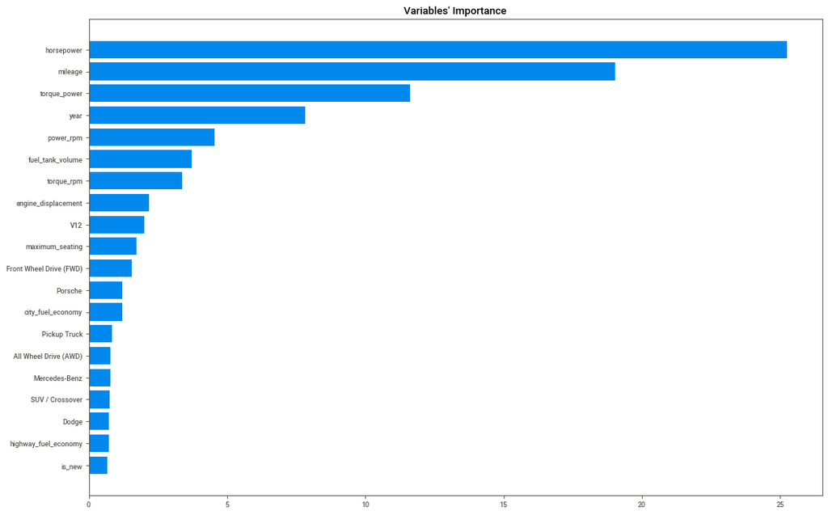

```python
from matplotlib.pyplot import figure
figure(figsize=(15, 10), dpi=80)

sorted_feature_importance = CBR.feature_importances_.argsort()
myX = X_train.columns[sorted_feature_importance]
myY = CBR.feature_importances_[sorted_feature_importance]
myX = myX[-20:]
myY = myY[-20:]
plt.barh(myX, myY)
plt.title("Variables' Importance")
plt.show()
```

## 6.3. Results

**We have successfully built a CatBoost Regressor using Python, which is capable of predicting 95% of the variability in US Used cars with an average error of 4,189.33$**  
**Additionally, we have looked at Variable Importance Plots and the features associated with US Used cars predictions. As it can be seen on the last plot, there are some variables that contribute a great deal to the model. These are "horsepower", "mileage", "torque_power" and "year".**

## 6.4. Model extraction to pickle

```python
pd.to_pickle(CBR, "../CBRModel_03092021_1")
```

# 7. Model Deployment

Once the dataset has been analyzed, cleaned, splitted and the model is producing good results, it had to be put into production so that customers could use it.

To do so, **we decided build a Django application and made it available online.** The project is hosted at **www.mileage.one**, but can also be run locally.  
**The project files are available on Github https://github.com/alvarico509/TFM**.

The basic operating structure of the application is as follows:

The application defines a vehicle model that is composed of the different variables that are taken into account to estimate the price.  
In the "model" tab of the website there is a form with the vehicle parameters.  
The form consists of cascading dependent dropdowns. This was achieved using jQuery (Javascript).  
The JSON extracted in section 4.11. of the notebook is used to feed the dropdowns.  
The machine learning model is extracted into a pickle file (section 6.4.) that is later loaded into the application.  
When the form is filled in and submitted, the variables are captured by a python function that processes them and feeds them into the model to estimate the price.  
Once the price is calculated, the application returns them to the HTML page along with the estimated price.

# 8. Sources

Catboost, CatBoost overview (2017), https://catboost.ai/  
CatBoost regression in 6 minutes, Towards Data Science (2018), https://towardsdatascience.com/catboost-regression-in-6-minutes-3487f3e5b329

```python
print("The code took", round((time.time() - start_time)/60), "minutes to run.")
```

```
The code took 43 minutes to run.
```